# NOAA Storm Data Exploration For The Most Harmful Events To Population Health And The Events That Have The Greatest Economic Consequences To The US

Adalberto Cubillo

8/22/2019

## Synopsis

This report explores the U.S. National Oceanic and Atmospheric Administration’s (NOAA) storm database. This database tracks characteristics of major storms and weather events in the United States, including when and where they occur, as well as estimates of any fatalities, injuries, and property damage.

The events in the database start in the year 1950 and end in November 2011. In the earlier years of the database there are generally fewer events recorded, most likely due to a lack of good records. More recent years should be considered more complete.

This data analysis main goal is to answer the following questions:

- Across the United States, which types of events are most harmful with respect to population health?
- Across the United States, which types of events have the greatest economic consequences?

To achieve this goal the first step was to process the storm data from NOAA database (which was provided as a comma separated values file).

Part of the data process was to perform a exploratory data analysis and transform some data (e.g. the economic damage information needed to be standardized).

After that, a comparison and a descriptive analysis was performed to establish which are the top 5 most harmful events in the US from people health and economic perspectives.

Finally, we concluded the most harmful events in the US are tornados and floods.

## Data Processing

First, we need to load the storm data to start the data analysis.

```r
# Load the data into a dataframe called "storm_data".
storm_data <- read.csv("repdata_data_StormData.csv.bz2", header = TRUE)
```

It is important to check overall information regarding the data that was just loaded. These details can provide insights on data transformations needed to be performed to data.

```r
# Let's check the first 6 rows of the dataframe.
head(storm_data)
```

```
##   STATE__           BGN_DATE BGN_TIME TIME_ZONE COUNTY COUNTYNAME STATE
## 1       1  4/18/1950 0:00:00     0130       CST     97     MOBILE    AL
## 2       1  4/18/1950 0:00:00     0145       CST      3    BALDWIN    AL
## 3       1  2/20/1951 0:00:00     1600       CST     57    FAYETTE    AL
## 4       1   6/8/1951 0:00:00     0900       CST     89    MADISON    AL
## 5       1 11/15/1951 0:00:00     1500       CST     43    CULLMAN    AL
## 6       1 11/15/1951 0:00:00     2000       CST     77 LAUDERDALE    AL
##    EVTYPE BGN_RANGE BGN_AZI BGN_LOCATI END_DATE END_TIME COUNTY_END
## 1 TORNADO         0                                               0
## 2 TORNADO         0                                               0
## 3 TORNADO         0                                               0
## 4 TORNADO         0                                               0
## 5 TORNADO         0                                               0
## 6 TORNADO         0                                               0
##   COUNTYENDN END_RANGE END_AZI END_LOCATI LENGTH WIDTH F MAG FATALITIES
```

[output cut: 20 more lines]

```r
# Also, let's figure out the attributes names and types.
names(storm_data)
```

```
##  [1] "STATE__"    "BGN_DATE"   "BGN_TIME"   "TIME_ZONE"  "COUNTY"
##  [6] "COUNTYNAME" "STATE"      "EVTYPE"     "BGN_RANGE"  "BGN_AZI"
## [11] "BGN_LOCATI" "END_DATE"   "END_TIME"   "COUNTY_END" "COUNTYENDN"
## [16] "END_RANGE"  "END_AZI"    "END_LOCATI" "LENGTH"     "WIDTH"
## [21] "F"          "MAG"        "FATALITIES" "INJURIES"   "PROPDMG"
## [26] "PROPDMGEXP" "CROPDMG"    "CROPDMGEXP" "WFO"        "STATEOFFIC"
## [31] "ZONENAMES"  "LATITUDE"   "LONGITUDE"  "LATITUDE_E" "LONGITUDE_"
## [36] "REMARKS"    "REFNUM"
```

```r
glimpse(storm_data)
```

```
## Observations: 902,297
## Variables: 37
## $ STATE__    <dbl> 1, 1, 1, 1, 1, 1, 1, 1, 1, 1, 1, 1, 1, 1, 1, 1, 1, 1,…
## $ BGN_DATE   <fct> 4/18/1950 0:00:00, 4/18/1950 0:00:00, 2/20/1951 0:00:…
## $ BGN_TIME   <fct> 0130, 0145, 1600, 0900, 1500, 2000, 0100, 0900, 2000,…
## $ TIME_ZONE  <fct> CST, CST, CST, CST, CST, CST, CST, CST, CST, CST, CST…
## $ COUNTY     <dbl> 97, 3, 57, 89, 43, 77, 9, 123, 125, 57, 43, 9, 73, 49…
## $ COUNTYNAME <fct> MOBILE, BALDWIN, FAYETTE, MADISON, CULLMAN, LAUDERDAL…
## $ STATE      <fct> AL, AL, AL, AL, AL, AL, AL, AL, AL, AL, AL, AL, AL, A…
## $ EVTYPE     <fct> TORNADO, TORNADO, TORNADO, TORNADO, TORNADO, TORNADO,…
## $ BGN_RANGE  <dbl> 0, 0, 0, 0, 0, 0, 0, 0, 0, 0, 0, 0, 0, 0, 0, 0, 0, 0,…
## $ BGN_AZI    <fct> , , , , , , , , , , , , , , , , , , , , , , , ,
## $ BGN_LOCATI <fct> , , , , , , , , , , , , , , , , , , , , , , , ,
## $ END_DATE   <fct> , , , , , , , , , , , , , , , , , , , , , , , ,
## $ END_TIME   <fct> , , , , , , , , , , , , , , , , , , , , , , , ,
```

[output cut: 24 more lines]

From the types and names functions we can identify the **EVTYPE** attribute for which the data stores the storm event types. Let´s figure out which are the top 10 storm events recorded in the dataset.

```r
# How many storm levels are recorded?
nlevels(storm_data$EVTYPE)
```

```
## [1] 985
```

```r
# Is there missing data?
sum(is.na(storm_data$EVTYPE)) > 0
```

```
## [1] FALSE
```

```r
# Top 10 most frequent events of all time.
storm_data %>%
  group_by(EVTYPE) %>%
  summarise(total_amount = n()) %>%
  arrange(desc(total_amount))
```

```
## # A tibble: 985 x 2
##    EVTYPE             total_amount
##    <fct>                     <int>
##  1 HAIL                     288661
##  2 TSTM WIND                219940
##  3 THUNDERSTORM WIND         82563
##  4 TORNADO                   60652
##  5 FLASH FLOOD               54277
##  6 FLOOD                     25326
##  7 THUNDERSTORM WINDS        20843
##  8 HIGH WIND                 20212
##  9 LIGHTNING                 15754
## 10 HEAVY SNOW                15708
## # … with 975 more rows
```

Within the dataset there are the variables **FATALITIES** and **INJURIES** which could give us some insights regarding this question. Let´s see if the data is complete and useful.

```r
# Let´s check min and max fatalities info.
summary(storm_data$FATALITIES)
```

```
##     Min.  1st Qu.   Median     Mean  3rd Qu.     Max.
##   0.0000   0.0000   0.0000   0.0168   0.0000 583.0000
```

```r
# Is there missing data?
sum(is.na(storm_data$FATALITIES)) > 0
```

```
## [1] FALSE
```

```r
# Let´s check min and max injuries info.
summary(storm_data$INJURIES)
```

```
##      Min.   1st Qu.    Median      Mean   3rd Qu.      Max.
##    0.0000    0.0000    0.0000    0.1557    0.0000 1700.0000
```

```r
# Is there missing data?
sum(is.na(storm_data$INJURIES)) > 0
```

```
## [1] FALSE
```

As we can see, there are no missing data nor malformed values.

There are also variables for the events that have the greatest economic consequences. These are: **PROPDMG**, **PROPDMGEXP**, **CROPDMG** and **CROPDMGEXP**. Let´s see if the data is complete and useful.

```r
# Let´s check min and max property damage info.
summary(storm_data$PROPDMG)
```

```
##    Min. 1st Qu.  Median    Mean 3rd Qu.    Max.
##    0.00    0.00    0.00   12.06    0.50 5000.00
```

```r
# Let´s check the exponents data.
summary(storm_data$PROPDMGEXP)
```

```
##             -      ?      +      0      1      2      3      4      5
## 465934      1      8      5    216     25     13      4      4     28
##      6      7      8      B      h      H      K      m      M
##      4      5      1     40      1      6 424665      7  11330
```

```r
# Is there missing data?
sum(is.na(storm_data$PROPDMG)) > 0
```

```
## [1] FALSE
```

```r
sum(is.na(storm_data$PROPDMGEXP)) > 0
```

```
## [1] FALSE
```

```r
# Let´s check min and max crop damage info.
summary(storm_data$CROPDMG)
```

```
##    Min. 1st Qu.  Median    Mean 3rd Qu.    Max.
##   0.000   0.000   0.000   1.527   0.000 990.000
```

```r
# Let´s check the exponents data.
summary(storm_data$CROPDMGEXP)
```

```
##             ?      0      2      B      k      K      m      M
## 618413      7     19      1      9     21 281832      1   1994
```

```r
# Is there missing data?
sum(is.na(storm_data$CROPDMG)) > 0
```

```
## [1] FALSE
```

```r
sum(is.na(storm_data$CROPDMGEXP)) > 0
```

```
## [1] FALSE
```

So, the exponent variables seems to have several values that can modify the damage data accordingly. For example, a PROPDMGEXP = “M” would infer the values are in millions or “K” will be in thousands. So we require to apply some transformations to **PROPDMG** and **CROPDMG**.

```r
# Get the real value applying the exponent.
apply_exp <- function(x, exp) {
  exponents <- get_exp(exp)
  result <- x * exponents

  return(result)
}

# Get the exponent value from the character format.
get_exp <- function(x) {
  sapply(x, function(x) {
    if (x == "k" | x == "K") {
      result <- 1000
    } else if (x == "m" | x == "M") {
      result <- 1000000
    } else if (x == "b" | x == "B") {
      result <- 1000000000
    } else if (as.integer(x)) {
      result <- 10
    } else {
      result <- 0
    }

    return(result)
  })
}

# A new dataset is created only with the damage data stored.
storm_data_dmg <- storm_data %>%
  select(EVTYPE, PROPDMG, PROPDMGEXP, CROPDMG, CROPDMGEXP) %>%
  mutate(prop_dmg_transf = apply_exp(PROPDMG, PROPDMGEXP),
         crop_dmg_transf = apply_exp(CROPDMG, CROPDMGEXP),
         total_dmg_transf = prop_dmg_transf + crop_dmg_transf)
head(storm_data_dmg)
```

```
##    EVTYPE PROPDMG PROPDMGEXP CROPDMG CROPDMGEXP prop_dmg_transf
## 1 TORNADO    25.0          K       0                      25000
## 2 TORNADO     2.5          K       0                       2500
## 3 TORNADO    25.0          K       0                      25000
## 4 TORNADO     2.5          K       0                       2500
## 5 TORNADO     2.5          K       0                       2500
## 6 TORNADO     2.5          K       0                       2500
##   crop_dmg_transf total_dmg_transf
## 1               0            25000
## 2               0             2500
## 3               0            25000
## 4               0             2500
## 5               0             2500
## 6               0             2500
```

This will produce a new dataset called **storm_data_dmg** which contains the property damage transformed to its full value (**prop_dmg_transf**), the crop damage transformed to its full value (**crop_dmg_transf**) and the total damage summing up both of them (**total_dmg_transf**).

## Results

Now let´s figure out which are the types of events that are most harmful with respect to population health in the US.

```r
# List the top 10 elements grouped by event type
# and based on the total population affectation (deaths + injuries).
storm_data_population_harm <- storm_data %>%
  select(EVTYPE, FATALITIES, INJURIES) %>%
  group_by(EVTYPE) %>%
  summarise(total_fatalities = sum(FATALITIES),
            total_injuries = sum(INJURIES),
            total_affected = total_fatalities + total_injuries) %>%
  arrange(desc(total_affected)) %>%
  head(10)
storm_data_population_harm
```

```
## # A tibble: 10 x 4
##    EVTYPE            total_fatalities total_injuries total_affected
##    <fct>                        <dbl>          <dbl>          <dbl>
##  1 TORNADO                       5633          91346          96979
##  2 EXCESSIVE HEAT                1903           6525           8428
##  3 TSTM WIND                      504           6957           7461
##  4 FLOOD                          470           6789           7259
##  5 LIGHTNING                      816           5230           6046
##  6 HEAT                           937           2100           3037
##  7 FLASH FLOOD                    978           1777           2755
##  8 ICE STORM                       89           1975           2064
##  9 THUNDERSTORM WIND              133           1488           1621
## 10 WINTER STORM                   206           1321           1527
```

So, apparently the top 5 most harmful events for population are: **tornados, excessive heat, thunderstorm winds, floods and lightnings**.

Regarding the types of events have the greatest economic consequences in the US we have the following:

```r
# List the top 10 elements grouped by event type
# and based on the total economic damage (properties + crops).
storm_data_economic_harm <- storm_data_dmg %>%
  select(EVTYPE, prop_dmg_transf, crop_dmg_transf, total_dmg_transf) %>%
  group_by(EVTYPE) %>%
  summarise(total_prop_dmg = sum(prop_dmg_transf),
            total_crop_dmg = sum(crop_dmg_transf),
            total_dmg = total_prop_dmg + total_crop_dmg) %>%
  arrange(desc(total_dmg)) %>%
  head(10)
storm_data_economic_harm
```

```
## # A tibble: 10 x 4
##    EVTYPE            total_prop_dmg total_crop_dmg    total_dmg
##    <fct>                      <dbl>          <dbl>        <dbl>
##  1 FLOOD               144657709870     5661968450 150319678320
##  2 HURRICANE/TYPHOON    69305840000     2607872800  71913712800
##  3 TORNADO              56937163467      414954710  57352118177
##  4 STORM SURGE          43323536000           5000  43323541000
##  5 HAIL                 15732269997     3025954680  18758224677
##  6 FLASH FLOOD          16140817081     1421317100  17562134181
##  7 DROUGHT               1046106000    13972566000  15018672000
##  8 HURRICANE            11868319010     2741910000  14610229010
##  9 RIVER FLOOD           5118945500     5029459000  10148404500
## 10 ICE STORM             3944928310     5022113500   8967041810
```

So we can conclude, regarding economic consequences, the top 5 most damaging events are: **floods, hurricanes, tornados, storm surges and hails**.

Here we can see the comparison between the most harmful events for population and the most damaging events with economic consequences.

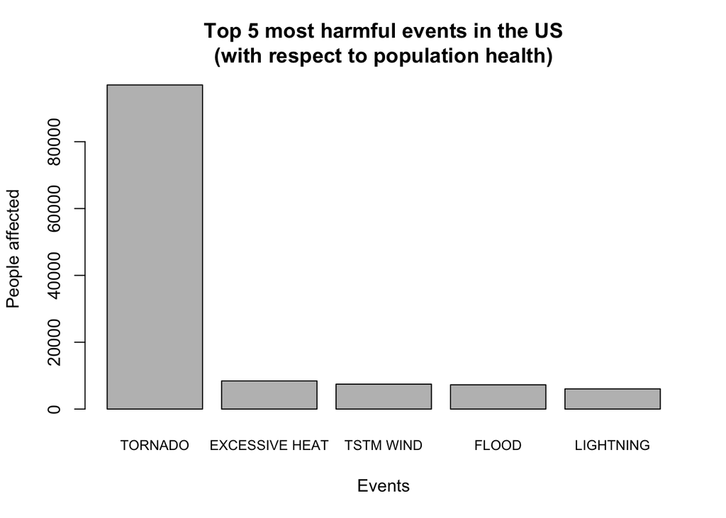

```r
# Show top 5 most harmful events in the US with respect to population health plot.
barplot(storm_data_population_harm$total_affected[1:5],
        xlab = "Events",
        ylab = "People affected",
        main = "Top 5 most harmful events in the US\n(with respect to population health)",
        names.arg = storm_data_population_harm$EVTYPE[1:5],
        cex.names = 0.8)
```

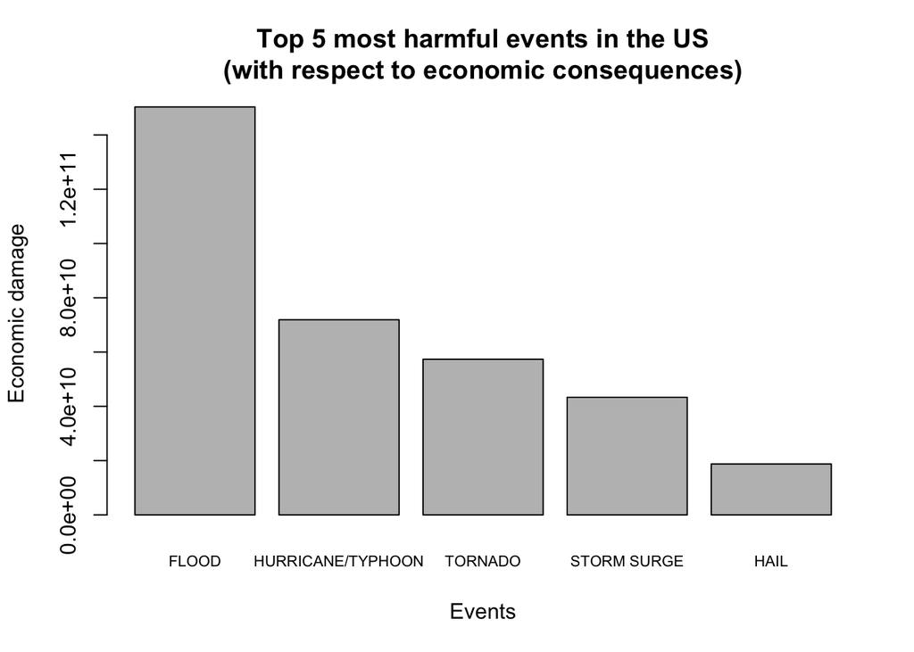

```r
# Show top 5 most harmful events in the US with respect to economic consequences plot.
barplot(storm_data_economic_harm$total_dmg[1:5],
        xlab = "Events",
        ylab = "Economic damage",
        main = "Top 5 most harmful events in the US\n(with respect to economic consequences)",
        names.arg = storm_data_economic_harm$EVTYPE[1:5],
        cex.names = 0.7)
```

As we can see **floods** and **tornados** appear in both lists and can be considered the most harmful events in the US overall.

## Further Work

As I deepen my exploratory analysis regarding the U.S. NOAA storm database, I found the following elements for improvement in the data exploration:

- **EVTYPE** needs to be cleaned up and some data needs to be merged. For example, there are several categories regarding wind issues: " WIND“,”WND“,”WINDS" and “Wind”. Same goes for other categories.
- **PROPDMGEXP** and **CROPDMGEXP** are not standardized across the years recorded. So, the records need to be cleaned up and reformatted. This URL present a guide to follow and understand the exponent values https://github.com/flyingdisc/RepData_PeerAssessment2/blob/master/how-to-handle-PROPDMGEXP.md